# Lab 2

We begin by importing all necessary dependencies

```python
from os import path
import pandas as pd
import urllib
import zipfile
import sys
import matplotlib.pyplot as plt
import numpy as np
import time
from sklearn.preprocessing import StandardScaler
import seaborn as sns
from sklearn.pipeline import Pipeline
from sklearn.linear_model import LinearRegression
from sklearn.preprocessing import StandardScaler
import datetime as dt
import timeit
from tqdm import tqdm
import math
from sklearn.metrics import r2_score
```

```python
# Increase Graph Resolution
%config InlineBackend.figure_format = 'retina'
```

We set the seed to make sure that our random values are the same

```python
np.random.seed(42)
```

# Exercice 1. (Time series analysis with pandas)

```python
url = u'https://archive.ics.uci.edu/ml/machine-learning-databases/00235/'
filename = 'household_power_consumption'
zipfilename = filename + '.zip'
Location = url + zipfilename

if not path.isfile(zipfilename):
    urllib.request.urlretrieve(location, zipfilename)

    zipfile.ZipFile(zipfilename).extractall()

na_values = ['?', '']
fields = ['Date', 'Time', 'Global_active_power']
df = pd.read_csv(filename + '.txt', sep=';', nrows=200000,
                 na_values=na_values, usecols=fields)

df.info()
```

```
<class 'pandas.core.frame.DataFrame'>
RangeIndex: 200000 entries, 0 to 199999
Data columns (total 3 columns):
 #   Column               Non-Null Count   Dtype
---  ------               --------------   -----
 0   Date                 200000 non-null  object
 1   Time                 200000 non-null  object
 2   Global_active_power  196268 non-null  float64
dtypes: float64(1), object(2)
memory usage: 4.6+ MB
```

# Question 1

1. Count the number of lines with missing values. Erase all such lines.

**We only focus on the Global_active_power feature for the moment.**

```python
df.shape
```

```
(200000, 3)
```

```python
# 1. Count the number of lines with missing values
df['Global_active_power'].isna().sum()
```

```
3732
```

```python
df[df['Global_active_power'].isna()]
```

|  | Date | Time | Global_active_power |
| --- | --- | --- | --- |
| 6839 | 21/12/2006 | 11:23:00 | NaN |
| 6840 | 21/12/2006 | 11:24:00 | NaN |
| 19724 | 30/12/2006 | 10:08:00 | NaN |
| 19725 | 30/12/2006 | 10:09:00 | NaN |
| 41832 | 14/1/2007 | 18:36:00 | NaN |
| ... | ... | ... | ... |
| 194215 | 30/4/2007 | 14:19:00 | NaN |
| 194216 | 30/4/2007 | 14:20:00 | NaN |
| 194217 | 30/4/2007 | 14:21:00 | NaN |
| 194218 | 30/4/2007 | 14:22:00 | NaN |
| 194219 | 30/4/2007 | 14:23:00 | NaN |

3732 rows × 3 columns

```python
# 2. Erase all rows with missing values
df.dropna(subset=['Global_active_power'], inplace=True)
```

```python
# 3. Print the updated DataFrame
df.shape
```

```
(196268, 3)
```

1. **Interpretation**:

We begin by identifying and counting the number of missing values (NaN) in the 'Global_active_power' column, with the result being 3732 missing values. This is visualized through a segment of the DataFrame output where 'Global_active_power' is NaN. The code then proceeds to remove these rows with missing values and prints the new shape of the DataFrame, which is (196268, 3), indicating the remaining number of rows and columns after the deletion process.

2. **Analysis**:

The initial count of missing values, which totals 3732, provides an overview of the dataset's completeness and the extent of missing data that needs addressing before any further analysis. The output, showing rows with NaN under 'Global_active_power', visually confirms the presence of missing data. After the code removes these identified missing values using `dropna(subset=['Global_active_power'], inplace=True)`, the resultant DataFrame shape, (196268, 3), is printed.

# Question 2

2. Use the pandas functions to_datetime and set_index to set a DateTimeIndex to df. You should first preserve the full date information, i.e. keep the hour, minute, seconds information in your newly created DateTime. Beware, when reading dates, that the international dates format that is different from the French standard. What’s the advantage of having a DateTimeIndex compared to a regular index?

```python
# So before the modifications our dataset looks like this
df.head()
```

|  | Date | Time | Global_active_power |
| --- | --- | --- | --- |
| 0 | 16/12/2006 | 17:24:00 | 4.216 |
| 1 | 16/12/2006 | 17:25:00 | 5.360 |
| 2 | 16/12/2006 | 17:26:00 | 5.374 |
| 3 | 16/12/2006 | 17:27:00 | 5.388 |
| 4 | 16/12/2006 | 17:28:00 | 3.666 |

```python
DateTime = pd.to_datetime(df['Date'] + df['Time'], format='%d/%m/%Y%H:%M:%S')
df = df.set_index(pd.DatetimeIndex(DateTime))
```

```python
# Convert 'Date' and 'Time' columns to datetime format

df['Date'] = pd.to_datetime(df['Date'], format='%d/%m/%Y')
df['Time'] = pd.to_datetime(df['Time'], format='%H:%M:%S').dt.time
```

```python
# And after the modifications our dataset looks like this
df.head()
```

|  | Date | Time | Global_active_power |
| --- | --- | --- | --- |
| 2006-12-16 17:24:00 | 2006-12-16 | 17:24:00 | 4.216 |
| 2006-12-16 17:25:00 | 2006-12-16 | 17:25:00 | 5.360 |
| 2006-12-16 17:26:00 | 2006-12-16 | 17:26:00 | 5.374 |
| 2006-12-16 17:27:00 | 2006-12-16 | 17:27:00 | 5.388 |
| 2006-12-16 17:28:00 | 2006-12-16 | 17:28:00 | 3.666 |

1. **Interpretation**:

This Python code aims at converting the date and time information from the 'Date' and 'Time' columns into a single DateTimeIndex for the DataFrame `df`. Initially, the DataFrame contains separate columns for 'Date' and 'Time'. The code concatenates these two columns into a single string and converts it to a DateTime object, subsequently setting it as the DataFrame index. Before the transformation, each row is indexed by a default integer. After the transformation, each row is indexed by the corresponding DateTime, as shown in the provided output.

2. **Analysis**:

### What’s the advantage of having a DateTimeIndex compared to a regular index?

It makes data manipulation and analysis more straightforward and efficient because:

- **a) Time Series Analysis:** Having a DateTimeIndex is useful for time series analysis. Many functions and methods in pandas are optimized for time series data, and having a DateTimeIndex ensures that these functions work correctly and efficiently.
- **b) Date/Time-Based Indexing:** You can index and slice your DataFrame based on specific dates, months, years, etc. This kind of slicing is intuitive and concise with a DateTimeIndex.
- **c) Resampling:** With a DateTimeIndex, you can easily resample your data. For example, you can convert daily data into monthly or yearly data using the resample method.
- **d) Rolling Window Calculations:** It's straightforward to compute rolling statistics, like moving averages, with a DateTimeIndex.
- **e) Date/Time Functions:** A DateTimeIndex allows for easy extraction of year, month, day, and other date parts. It also supports calculations that take into account the intricacies of the calendar and time, such as leap years.
- **f) Shifts and Lags:** You can easily shift or lag data in a time-aware manner.
- **g) Frequency Detection:** Pandas can automatically infer the frequency of your data (e.g., daily, monthly).

# Question 3

3. Display the graphic of daily averages, between January 1 2007 and April 30 2007. Propose an explanation for the consumption behavior between February and early April.

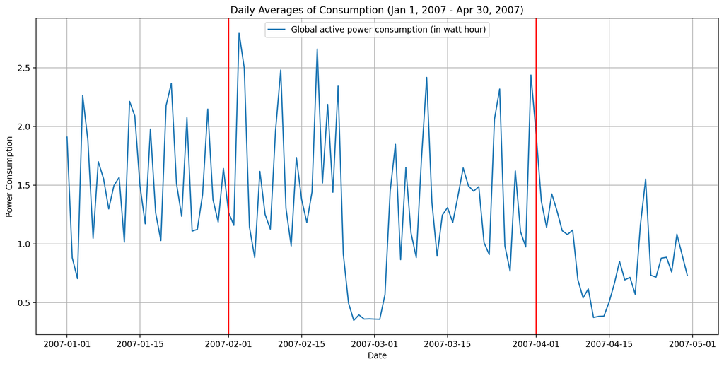

```python
# Filter data for the specified date range
df_filtered = df['2007-01-01': '2007-04-30']

# Group by date and calculate daily averages
daily_avg = df_filtered.groupby(df_filtered['Date'])['Global_active_power'].mean()

plt.figure(figsize=(15, 7))

plt.plot(daily_avg.index, daily_avg.values, label = "Global active power consumption (in watt hour)")

#Period to analyse
plt.axvline(dt.datetime(2007, 2, 1), color='red')
plt.axvline(dt.datetime(2007, 4, 1), color='red')

# Labeling and Title
plt.title('Daily Averages of Consumption (Jan 1, 2007 - Apr 30, 2007)')
plt.xlabel('Date')
plt.ylabel('Power Consumption')


plt.legend()
plt.grid(True)
plt.show()
```

1. **Interpretation:**

2. **Analysis:**

The provided code aims to visualize the trend in daily average power consumption over a defined date range.

### Propose an explanation for the consumption behavior between February and early April.

The red lines mark the timeframe from February to April. Generally speaking we see a downward sloping trend starting from the beginning of March. This overall trend is heavily fluctuating though from day/ week to day/ week.

More suprising and noticable is the slump from around the **22nd of February** to the **3rd of March**. While we admittedly don't have a perfect explanation for this, especially given the stark increase again, at the beginning of March, here are a couple of ideas:

- Measurement error
- Change in measurement methodolgy (although that would not explain the bounce back)
- The deleted/ droped rows disproportionately effected this period.
- Unrepresentative data. Although "Global Consumption" is indicated, maybe data was actually only collected locally.
- Europe was experiencing an unusually hot period during this time, which would explain the slump in energy consumption during this period on the continent (as less energy is used for eg heating).
- A spike in energy cost. A sharp increase in energy cost could explain the slump in demand.

# Question 4

4. Load the dataset TG_STAID011249.txt with pandas, and keep only the DATE and TG columns. Divide by 10 the TG column to get Celsius temperature. Treat missing values as NaNs.

```python
df_temp_orly = pd.read_csv("TG_STAID011249.txt", comment='#', na_values=['NA', 'N/A', 'nan', ''])
```

```python
# /!\ Here, there are extra spaces in the column names so we will remove these extra spaces
print("These are the column names BEFORE stripping whitespaces\n", df_temp_orly.columns)

df_temp_orly.columns = df_temp_orly.columns.str.strip()
print("\nThese are the column names AFTER stripping whitespaces\n", df_temp_orly.columns)
```

```
These are the column names BEFORE stripping whitespaces
 Index(['STAID', ' SOUID', '    DATE', '   TG', ' Q_TG'], dtype='object')

These are the column names AFTER stripping whitespaces
 Index(['STAID', 'SOUID', 'DATE', 'TG', 'Q_TG'], dtype='object')
```

```python
# 2. Select only the 'DATE' and 'TG' columns
df_temp_orly = df_temp_orly[['DATE', 'TG']]

# 3. Divide the 'TG' column by 10 to get Celsius temperature
df_temp_orly['TG'] = df_temp_orly['TG'] / 10

# 4. Treat missing values as NaNs.
df_temp_orly['TG'].replace([-9999, -999.9], np.nan, inplace=True)
# Replacing with NaNs (-9999, -999.9: This is the value in the 'TG' column that represents a missing or
# unavailable data point. In many datasets, especially in scientific contexts, sentinel values like -999.9)

# Set the 'DATE' column as a datetime index
df_temp_orly['DATE'] = pd.to_datetime(df_temp_orly['DATE'],  format='%Y%m%d')  # The date format is 'YYYYMMDD'


print("After, our dataset looks like this:\n")
df_temp_orly.head()
```

```
After, our dataset looks like this:
```

|  | DATE | TG |
| --- | --- | --- |
| 0 | 1921-03-01 | 5.0 |
| 1 | 1921-03-02 | 4.6 |
| 2 | 1921-03-03 | 4.6 |
| 3 | 1921-03-04 | 3.1 |
| 4 | 1921-03-05 | 9.5 |

# Question 5

5. Create a pandas Time Series with the daily temperatures between January 1 2007 and April 30 2007. Display on the same graph the temperature and the Global_active_power Time Series. Using a twinx axis might help to display 2 series of values with different magnitudes in a readable fashion.

```python
mask = (df_temp_orly['DATE'] >= '2007-01-01') & (df_temp_orly['DATE'] < '2007-05-01')
df_temp_orly_filtered = df_temp_orly[mask]
df_temp_orly_filtered.head()
```

|  | DATE | TG |
| --- | --- | --- |
| 31352 | 2007-01-01 | 9.6 |
| 31353 | 2007-01-02 | 6.0 |
| 31354 | 2007-01-03 | 6.1 |
| 31355 | 2007-01-04 | 9.2 |
| 31356 | 2007-01-05 | 10.0 |

```python
# Merging the two DataFrames on the 'DATE' column of df_temp_orly_filtered.
df_combined = pd.merge(df_temp_orly_filtered, daily_avg, left_on='DATE', right_on='Date', how='outer')
df_combined.isna().sum()
```

```
DATE                   0
TG                     0
Global_active_power    1
dtype: int64
```

```python
# Filling nan values with last (previous) valid row value.
# This can be problematic but given that we only have one missing value (for the Global active power consumption on the 29th of April) we deemed this step ok.
df_combined = df_combined.fillna(method='ffill')
```

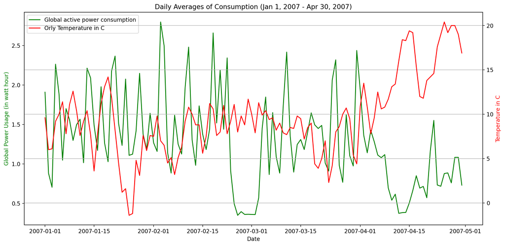

```python
# Create a figure
fig, ax1 = plt.subplots(figsize=(15, 7))

# Set the x-axis label
ax1.set_xlabel('Date')

# Plot the global active power on the first axis (left)
#plt.plot(daily_avg.index, daily_avg.values, label = "Global active power consumption (in watt hour)")

lns1 = ax1.plot(df_combined['DATE'], df_combined['Global_active_power'], 'g', label='Global active power consumption')
ax1.set_ylabel('Global Power Usage (in watt hour)', color='g')

# Create a second axis (right)
ax2 = ax1.twinx()

# Plot the temperature on the second axis (right)
lns2 = ax2.plot(df_combined['DATE'], df_combined['TG'], 'r', label='Orly Temperature in C')
ax2.set_ylabel('Temperature in C', color='r')

# Combine legends from both axes
lns = lns1 + lns2
labs = [l.get_label() for l in lns]

# Display a single legend for both plots
ax1.legend(lns, labs, loc='upper left')

# Set a title
plt.title('Daily Averages of Consumption (Jan 1, 2007 - Apr 30, 2007)')

# Display grid
plt.grid(True)

# Show the plot
plt.show()
```

```python
np.corrcoef(df_combined.dropna()['Global_active_power'], df_combined.dropna()['TG'])
```

```
array([[ 1.        , -0.35970876],
       [-0.35970876,  1.        ]])
```

**Interpretation and Analysis:**

Our code filters the dataset to select temperature data between January 1, 2007, and April 30, 2007, and stores this filtered data in `df_temp_orly_filtered`. Subsequently, it initiates the creation of a plot with specified dimensions.

This visualization is crucial for observing and analyzing the relationship between daily average global active power consumption and daily temperature in Orly from January 1, 2007, to April 30, 2007. The dual-axis technique allows for the simultaneous representation of temperature and power consumption without losing the granularity of data due to the difference in their scales.

We can see in the above displayed pearson correlation coefficient, that on average, as the measured temperature is rising (in Orly), the global power usage in watt hour is decreasing, and vice versa (negative correlation). This makes sense as probaboly a great deal of houslod power consumption is related to heating - which becomes less relevant when warmer.

Our previous interpretation of the slump in energy consumption, as related to an unusually warm winter/ spring in Europe during that time does not align with what we see here in the graph.

# Exercice 2. (Linear algebra)

We remind the following linear algebra fact: for any $X \in \mathbb{R}^{n \times p}$ and $\mathbf{y} \in \mathbb{R}^{n}$ the following equation holds true:

$$ X^{\top}\left(X X^{\top}+\lambda \operatorname{Id}_{n}\right)^{-1} \mathbf{y}=\left(X^{\top} X+\lambda \operatorname{Id}_{p}\right)^{-1} X^{\top} \mathbf{y} $$

# Question 6

6. Check this property numerically for $\lambda=10^{-5}$ without inverting any matrix. To compute $A^{-1} b$, never invert directly $A$ : solve the linear system $A x=b$ with np.linalg.solve ${ }^{3}$, for a matrix $X$ whose entries are generated randomly (i.i.d.) according to a Gaussian distribution with mean zero and variance 5 , and for a vector $\mathbf{y}$ with coordinates generated randomly (i.i.d.) according to a uniform distribution over $[-1,1]$,

(a) check it for $n=100$ and $p=2000$,

(b) check it for $n=2000$ and $p=100$.

```python
# Step 1: Define your matrices and vector
def generate_matrix_and_vector(n, p):
    # Matrix X with Gaussian distribution entries
    X = np.random.normal(0, np.sqrt(5), (n, p))
    # Vector y with uniform distribution entries
    y = np.random.uniform(-1, 1, n)
    return X, y

# Step 2: Implement the two sides of the equation
def compute_equation_left(X, y, lambd):
    n, p = X.shape
    # Left-hand side
    term_lhs = X @ X.T + lambd * np.eye(n)
    lhs = X.T @ np.linalg.solve(term_lhs, y)
    return lhs

def compute_equation_right(X, y, lambd):
    n, p = X.shape
    # Right-hand side
    term_rhs = X.T @ X + lambd * np.eye(p)
    rhs = np.linalg.solve(term_rhs, X.T @ y)
    return rhs

# Verify for a given (n, p) configuration
def verify_for_dimensions(n, p, lambd=1e-5):
    X, y = generate_matrix_and_vector(n, p)
    lhs, rhs = compute_equation_left(X, y, lambd), compute_equation_right(X, y, lambd)
    # We use np.allclose to check if the arrays are numerically close
    return np.allclose(lhs, rhs)

# Step 3: Verify for both cases
print('In the case of n=100 and p=2000: ', verify_for_dimensions(100, 2000))    # For (a)
print('In the case of n=2000 and p=100: ', verify_for_dimensions(2000, 100))    # For (b)

# Remark: due to the nature of floating-point arithmetic, you might get very tiny differences between the two results,
# even if they're theoretically supposed to be identical. This is why np.allclose is often used in such scenarios as it provides a tolerance level.
```

```
In the case of n=100 and p=2000:  True
In the case of n=2000 and p=100:  True
```

1. **Interpretation:**

The Python code essentially tests the given linear algebra property numerically for ( \lambda = 10^{-5} ). Two sets of dimensions for matrix ( X ), namely ( n=100, p=2000 ) and ( n=2000, p=100 ), are used for this validation. The function `generate_matrix_and_vector(n, p)` is used to generate a matrix ( X ) with entries following a Gaussian distribution (with mean zero and variance 5), and a vector ( y ) with entries uniformly distributed between ([-1, 1]). The `compute_equation_left` and `compute_equation_right` functions compute the left-hand side and right-hand side of the given equation respectively, using `np.linalg.solve` to solve the respective linear systems without directly inverting any matrix. The `verify_for_dimensions(n, p, lambd=1e-5)` function then checks whether the computed left-hand side and right-hand side are numerically close using `np.allclose`.

2. **Analysis:**

The numerical verification is conducted for two scenarios, providing a practical check for the robustness of the given linear algebra property across different matrix sizes. Using `np.linalg.solve` is crucial as it is a more numerically stable and efficient way to solve linear systems compared to directly inverting matrices, which can amplify numerical errors especially when dealing with ill-conditioned matrices. The `np.allclose` function is employed to assert the equality of the left-hand side and right-hand side of the equation, considering potential minor numerical discrepancies due to floating-point arithmetic. The tolerance level embedded within `np.allclose` ensures that minor differences (that may arise due to the limitations of numerical precision in computers) are acknowledged, providing a practical and reliable means of comparison. Since the function returns `True` for both sets of dimensions, it empirically validates the given linear algebraic property under the tested scenarios.

# Question 7

7. For a few scenarios similar to (a) and (b) $(n \ll p, p \ll n)$, do a short numerical/graphical study to compare (according to $n$ and $p$ ) when it is more time efficient to compute the quantity in (1) using the left hand side formulation or right hand side formulation. Explain the results.

```python
# Our scenario:
# Measure execution time for the left-hand side formulation
def time_lhs(X, y, lambd=1e-5):
    start_time = time.time()
    compute_equation_left(X, y, lambd)
    return time.time() - start_time

# Measure execution time for the right-hand side formulation
def time_rhs(X, y, lambd=1e-5):
    start_time = time.time()
    compute_equation_right(X, y, lambd)[1]
    return time.time() - start_time

# Define ranges for n and p
n_range = np.linspace(100, 2000, 100, dtype=int)
p_range = np.linspace(2000, 100, 100, dtype=int)

# Lists to store computation times
lhs_times = []
rhs_times = []

# Perform experiments for different values of n and p
for n, p in tqdm(zip(n_range, p_range)):
    X, y = generate_matrix_and_vector(n, p)

    # Temporary lists to store multiple measurements
    temporary_lhs = []
    temporary_rhs = []

    # For better accuracy run each combination 10 times.
    for i in range(10):
        temporary_lhs.append(time_lhs(X, y))
        temporary_rhs.append(time_rhs(X, y))

    # Average the computation times
    averaged_times_lhs = sum(temporary_lhs) / len(temporary_lhs)
    averaged_times_rhs = sum(temporary_rhs) / len(temporary_rhs)

    lhs_times.append(averaged_times_lhs)
    rhs_times.append(averaged_times_rhs)
```

```
100it [01:24,  1.18it/s]
```

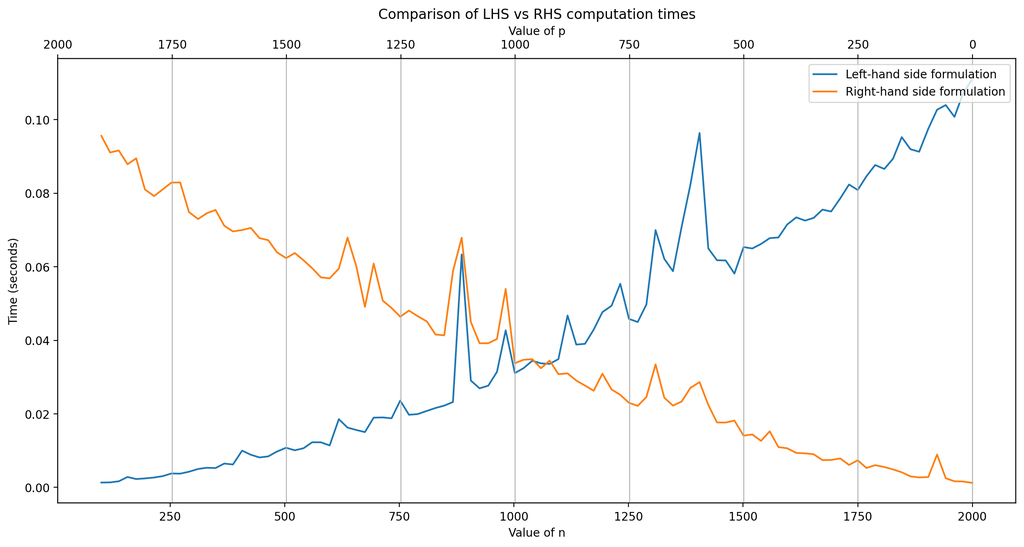

```python
# Plot the results
fig = plt.figure(figsize = (15, 7))

ax1 = fig.add_subplot(111)
ax2 = ax1.twiny()

l1 = ax1.plot(n_range, lhs_times, label='Left-hand side formulation')
l2 = ax1.plot(n_range, rhs_times, label='Right-hand side formulation')

ax1.set_xlabel(r"Value of n")
ax2.set_xlabel(r"Value of p")

ax1.set_ylabel(r"Time (seconds)")


ax2.set_xlim(ax1.get_xlim())
ax2.set_xticks([*range(0, 2250, 250)])
ax2.set_xticklabels([*range(0, 2250, 250)][::-1])

# Add legend
lns = l1 + l2
labs = [l.get_label() for l in lns]
ax2.legend(lns, labs, loc=0)


plt.title('Comparison of LHS vs RHS computation times')
plt.grid()
plt.show()
```

1. **Interpretation:**

The Python code provided conducts a numerical study by comparing the computation time between the left-hand side (LHS) and right-hand side (RHS) formulations of an equation across various scenarios. It initializes a range of `n` and `p` values, systematically generates matrices and vectors with these values, and computes the LHS and RHS of the equation multiple times, averaging the results. The computation times for both sides of the equation are plotted against the `n` values, where each plot point represents the average time taken for the computations at a particular `n` value.

2. **Analysis:**

The core of this numerical study is to understand the computational efficiency between two different approaches (LHS and RHS formulations) under varying conditions represented by the parameters `n` and `p`. The for-loop iterates through the zipped `n_range` and `p_range`, performing multiple timed computations for both LHS and RHS formulations, and then calculates the average computation time for each scenario. These averaged times are then plotted for visual comparison.

This graphical representation provides insights into the efficiency dynamics between the LHS and RHS formulations as `n` and `p` vary. From the graph, we can interpret that the formulation that is the more time-efficient when n is big is the Right Hand Side One.

**Important remark about our code here**

In this specific instance using time.time() instead of the Jupyter Notebook magic function %%timeit has advantages and considerations. It is used for precise control over timing measurements, repeated measurements over multiple runs, and **custom aggregation of execution times**. This choice allows for a **more versatile and flexible approach when conducting a numerical and graphical study** comparing computation times for different scenarios of n and p.

# Exercice 3. (Random matrix spectrum)

# Question 8

8. Choose three non-Gaussian probability distributions, with mean 0 and variance 2 , and write a function that takes as input $n, p$ and the distribution name, and creates a matrix $X \in \mathbb{R}^{n \times p}$ with entries generated (i.i.d.) according to this distribution.
- **Laplace distribution (with mean 0, variance 2):** The scale parameter is given by $$ b = 1 $$ The probability density function (pdf) is: $$ f(x|b) = \frac{1}{2b} e^{-\frac{|x|}{b}} $$
- **Triangular distribution:** For variance 2 and a=$$2\sqrt{3}$$ the range is $$ [-2\sqrt{3}, 2\sqrt{3}] $$ with peak at 0. The pdf is: $$ f(x|a) = \begin{cases} \frac{x}{a^2} + \frac{1}{a} & \text{for } -a \le x < 0 \\ -\frac{x}{a^2} + \frac{1}{a} & \text{for } 0 \le x \le a \end{cases} $$
- **Uniform distribution:** The range is $$ [-\sqrt{6},\sqrt{6}] $$ to achieve a variance of 2. So and a=$$\sqrt{6}$$ The pdf is: $$ f(x|a) = \frac{1}{2a} \text{ for } -a \le x \le a $$

```python
def generate_matrix(n, p, distribution):
    """
    Generate a matrix of size (n, p) with i.i.d. entries from the specified distribution.

    Parameters:
    n (int): Number of rows.
    p (int): Number of columns.
    distribution (str): Distribution name, one of ['laplace', 'triangular', 'uniform'].

    Returns:
    np.ndarray: Generated matrix.
    """
    if distribution == 'laplace':
        # Laplace distribution with mean 0 and variance 2
        return np.random.laplace(0, 1, (n, p))

    elif distribution == 'triangular':
        # Triangular distribution with mean 0 and variance 2
        a = -2*np.sqrt(3)
        b = 2*np.sqrt(3)
        mode = 0
        return np.random.triangular(a, mode, b, (n, p))

    elif distribution == 'uniform':
        # Uniform distribution with mean 0 and variance 2
        a = -np.sqrt(6)
        b = np.sqrt(6)
        return np.random.uniform(a, b, (n, p))

    else:
        raise ValueError(f"Unsupported distribution: {distribution}")


# Let's try our code:
X_laplace = generate_matrix(5000, 5000, 'laplace')

X_triangular = generate_matrix(5000, 5000, 'triangular')

X_uniform = generate_matrix(5000, 5000, 'uniform')
```

```python
print(f'For the Laplace Distribution the (rounded) mean is: {round(X_laplace.mean())}, and the (rounded) variance is: {round(X_laplace.var())}')
print(f'For the Triangular Distribution the (rounded) mean is: {round(X_triangular.mean())}, and the (rounded) variance is: {round(X_triangular.var())}')
print(f'For the Uniform Distribution the (rounded) mean is: {round(X_uniform.mean())}, and the (rounded) variance is: {round(X_uniform.var())}')
```

```
For the Laplace Distribution the (rounded) mean is: 0, and the (rounded) variance is: 2
For the Triangular Distribution the (rounded) mean is: 0, and the (rounded) variance is: 2
For the Uniform Distribution the (rounded) mean is: 0, and the (rounded) variance is: 2
```

1. **Interpretation:**

The `generate_matrix` function in the code takes three parameters: `n`, `p`, and `distribution`. It generates a n*p matrix `X` with entries independently and identically distributed (i.i.d.) according to the specified non-Gaussian distribution: Laplace, Triangular, or Uniform. The function then returns a matrix with entries generated according to these parameters for the chosen distribution.

2. **Analysis:**

The use of NumPy’s random module functions (`np.random.laplace`, `np.random.triangular`, and `np.random.uniform`) facilitates the generation of random numbers from the specified distributions, allowing for the creation of matrices with the desired statistical properties. The error handling mechanism in place ensures that unsupported distribution inputs are immediately flagged, promoting code robustness and reliability during function calls. In accordance to the documentation for each of the distributions, we adjusted the parameters to achieve mean=0 and variance= 2.

# Question 9

9. Display on one single graph the singular values of $X$ for $n=1000$, and $p=200,500,1000,2000$ for the three distributions chosen.

```
Laplace Distribution
p=200  . Mean: 43.63452675173185    Variance: 105.31667462684977
p=500  . Mean: 41.74084748521175    Variance: 260.0241995162475
p=1000 . Mean: 37.99003610264726    Variance: 561.9979858881186
p=2000 . Mean: 58.940086112938936   Variance: 520.4268127042302


Triangular Distribution
p=200  . Mean: 43.6773401048188     Variance: 102.02377098891655
p=500  . Mean: 41.69011876586884    Variance: 260.22532020922444
p=1000 . Mean: 38.013278525916334   Variance: 560.6709539750856
p=2000 . Mean: 58.97882673046376    Variance: 517.9888211989978


Uniform Distribution
p=200  . Mean: 43.55473471326751    Variance: 101.39592618325624
p=500  . Mean: 41.71102456338316    Variance: 260.0274197688676
p=1000 . Mean: 37.94775618561833    Variance: 558.3935427775514
p=2000 . Mean: 58.96841311436752    Variance: 519.911510516416
```

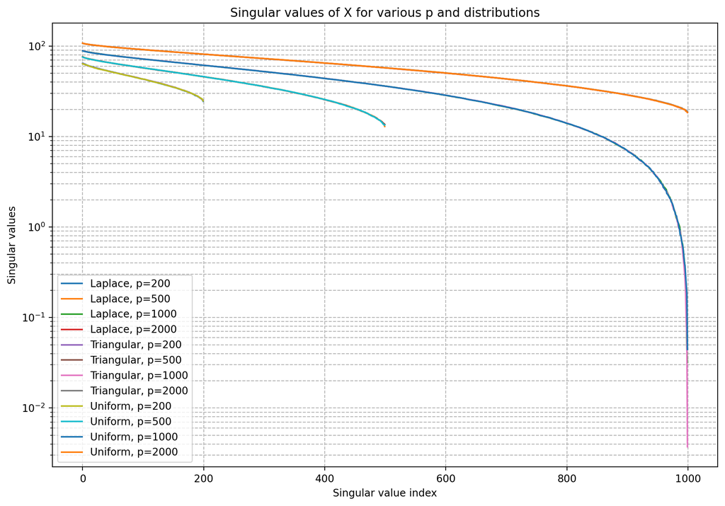

```python
# Values
n = 1000
p_values = [200, 500, 1000, 2000]
distributions = ['laplace', 'triangular', 'uniform']

# Prepare plot
plt.figure(figsize=(10,7))

for distribution in distributions:
    print(distribution.capitalize(), 'Distribution')
    for p in p_values:
        X = generate_matrix(n, p, distribution)
        singular_values = np.linalg.svd(X, compute_uv=False) # Compute singular values
        print(f'p={p: <5}. Mean: {singular_values.mean(): <20} Variance: {singular_values.var(): <20}')
        label = f'{distribution.capitalize()}, p={p}'
        plt.plot(singular_values, label=label)
    print('\n')

# Configure and display the plot
plt.title('Singular values of X for various p and distributions')
plt.xlabel('Singular value index')
plt.ylabel('Singular values')

# Comment in case you want to display the y axis in linear format
plt.yscale('log')

plt.legend()
plt.grid(True, which="both", ls="--", c='0.7')
plt.tight_layout()
plt.show()
```

1. **Interpretation:**

Three different non-Gaussian distributions - 'laplace', 'triangular', and 'uniform' - are specified. For each combination of distribution and `p` value, the code generates a matrix `X` using the `generate_matrix` function from earlier . The singular values of each `X` matrix are computed using NumPy’s Singular Value Decomposition (`np.linalg.svd`) function, with the `compute_uv` parameter set to `False` to obtain only the singular values. These values are then plotted on a logarithmic scale graph, labeled appropriately to reflect the corresponding distribution type and `p` value.

2. **Analysis:**

# Question 10

10. Display on one single graph the spectrum (i.e. the set of eigen values) of $X^{\top} X / n$ for $n=1000$, and $p=200,500,1000,2000$. Comment.

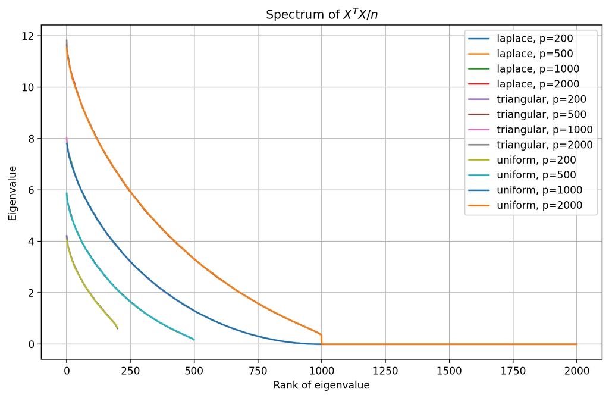

```python
# Define parameters
n = 1000  # Number of data points
p_values = [200, 500, 1000, 2000]  # Different values for the number of features (columns)
distributions = ['laplace', 'triangular', 'uniform']  # Different data distribution types

# Create a figure for the plot
plt.figure(figsize=(10, 6))

# Loop through each distribution type
for distribution in distributions:

    # Loop through each value of p (number of features)
    for p in p_values:

        # Generate a random data matrix X with specified distribution and dimensions
        X = generate_matrix(n, p, distribution)

        # Calculate the sample covariance matrix by multiplying X with its transpose and dividing by n
        matrix = np.dot(X.T, X) / n

        # Compute the eigenvalues of the sample covariance matrix in ascending order
        eigenvalues = np.linalg.eigvalsh(matrix)

        # Plot the sorted eigenvalues in reverse order, label with distribution type and p value
        plt.plot(sorted(eigenvalues, reverse=True), label=f'{distribution}, p={p}')

# Set plot title and labels
plt.title("Spectrum of $X^{T} X / n$")
plt.xlabel("Rank of eigenvalue")
plt.ylabel("Eigenvalue")
plt.legend()
plt.grid(True)
plt.show()
```

## Comments

1. **Interpretation:**

We represent the spectrum of the matrix expression $X^{\top} X / n$ for matrices $X$ with dimensions nxp. For each value of $p$, matrices $X$ are created with entries drawn from Laplace, Triangular, and Uniform distributions, and then the expression $X^{\top} X / n$ is computed. The eigenvalues of this result are calculated, sorted in descending order, and plotted. Each line on the graph corresponds to a combination of distribution type and $p$ value, labeled accordingly.

2. **Analysis:**

We note that :

**1000 x 2000 Rank Deficiency:** In a rank-deficient matrix, there are linear dependencies among its rows or columns, leading to fewer linearly independent directions. Consequently, the number of nonzero eigenvalues is less than or equal the matrix's smaller dimension, indicating redundant information and reduced effective dimensionality in the data. This relationship is pivotal in dimensionality reduction and data analysis.

**Eigenvalues Decrease:** For all distributions and values of `p`, the eigenvalues of the matrix $X^{\top} X / n$ are plotted in descending order. This means that the first eigenvalue has the highest magnitude, followed by the second eigenvalue, and so on.

**Eigenvalue Spread:** As `p` increases, the spread or range of eigenvalues also increases. In other words, the difference in magnitudes between the largest and smallest eigenvalues becomes more significant as dimensionality (`p`) grows.

**Interpretation:**

The observed behavior is in line with spectral analysis in high-dimensional spaces. In high-dimensional data, the spectrum of $X^{\top} X / n$ often exhibits a pattern where a small number of eigenvalues have significant magnitudes, while the majority have much smaller magnitudes. The spread in eigenvalues with increasing `p` reflects the growing complexity and variability of data in higher dimensions, known as the "curse of dimensionality."

# Exercice 4. (Power method)

We consider a matrix $X \in \mathbb{R}^{n \times p}$ generated as in Exercise 2, question 1), for $(n, p)=(200,400)$.

# Question 11

11. Write a function coding Algorithm 1.

The algorithm aims to converge to the dominant left and right singular vectors of `X`. The output `u` approximates the leading left singular vector of `X` corresponding to the largest singular value of `X`, and `v` approximates the leading right singular vector corresponding to that same singular value.

```python
def power_method(X, T):
    n, p = X.shape
    v = np.random.rand(p)

    # Perform T iterations of the power method
    for k in range(T):
        # Compute the u vector by multiplying X with the current v
        u_part = np.dot(X, v)

        # Normalize the u vector to have unit length
        u = u_part / np.linalg.norm(u_part)

        # Compute the v vector by multiplying X transpose with the current u
        v_part = np.dot(X.T, u)

        # Normalize the v vector to have unit length
        v = v_part / np.linalg.norm(v_part)

    return u, v
```

```python
# Generate matrix X for (n, p)=(200,400)
n, p = 200, 400
X, _ = generate_matrix_and_vector(n, p)

# Let's test the power method
T = 100
u, v = power_method(X, T)

print("u from power method:", u)
print("v from power method:", v)
```

[output not shown]

[output cut: 79 more lines]

[output not shown]

1. **Interpretation:**

The `power_method` function implements Algorithm 1, aiming to converge to the dominant left and right singular vectors of a given matrix ( X ). The function receives a matrix ( X ) and the number of iterations ( T ), and it returns two vectors ( u ) and ( v ). Vector ( u ) approximates the leading left singular vector of ( X ), and vector ( v ) approximates the leading right singular vector. Both vectors correspond to the largest singular value of ( X ). The function initializes ( v ) with a random vector and iteratively refines ( u ) and ( v ) using the power method.

2. **Analysis:**

The implementation presented is simple and easy to understand, but some factors require consideration. Firstly, the convergence speed of the power method depends on the ratio between the leading eigenvalue and the subdominant ones. If this ratio is not significantly large, convergence might be slow. Initialization of the vector ( v ) with random values might lead to different results upon different function calls, making the method non-deterministic.

# Question 12

12. Modify the implementation of the algorithm to store all iterates of $u$ and $v$. Let $u^{*}$ (resp. $v^{*}$ ) be the leading left (resp. right) singular vector of $X$. Compute them using `np.linalg.svd`. Plot the norm of $u_{k}-u^{*}$ as a function of $k$. Is it true that the output $u, v$ from the algorithm converge to $u^{*}, v^{*}$ ? Run your code several times. Bonus: can you show it mathematically?

```python
def modified_power_method(X, T):
    n, p = X.shape
    v = np.random.rand(p)
    u_iterates = []
    v_iterates = []
    for k in range(T):

        u_part = np.dot(X, v)
        u = u_part / np.linalg.norm(u_part)

        v_part = np.dot(X.T, u)
        v = v_part / np.linalg.norm(v_part)

        u_iterates.append(u)   # to store all iterates of u and v
        v_iterates.append(v)

    return u_iterates, v_iterates
```

```python
def generate_graph(n, p):
    X, _ = generate_matrix_and_vector(n, p)

    # Compute u* and v* using SVD
    U, S, Vt = np.linalg.svd(X, full_matrices=False)

    u_star = U[:, 0]
    v_star = Vt[0, :]

    T = 100
    u_iterates, v_iterates = modified_power_method(X, T)

    plt.figure(figsize=(10, 6))

    # Compute the norm difference between iterates and true singular vectors
    u_differences = [np.linalg.norm(u - u_star) for u in u_iterates]
    v_differences = [np.linalg.norm(v - v_star) for v in v_iterates]

    # Plot the norm difference as a function of k
    plt.plot(range(T), u_differences, label="||u_k - u*||", color="blue")
    plt.plot(range(T), v_differences, label="||v_k - v*||", color="red")

    plt.xlabel("Iteration k")
    plt.ylabel("Norm difference")
    plt.legend()
    plt.grid()
    plt.title("Sequences (u_k) and (v_k) tend to converge (and occasionally diverge) toward the leading left (resp right) singular vectors of X")
    plt.show()
```

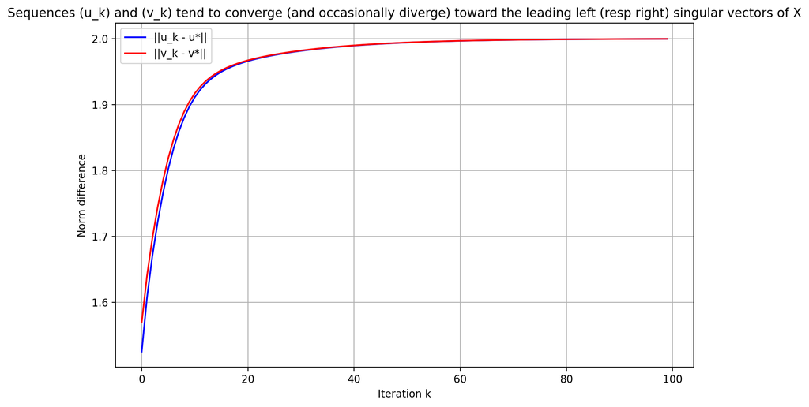

```python
# Generate matrix X for (n, p)=(200,400)
n, p = 200, 400
generate_graph(n, p)
```

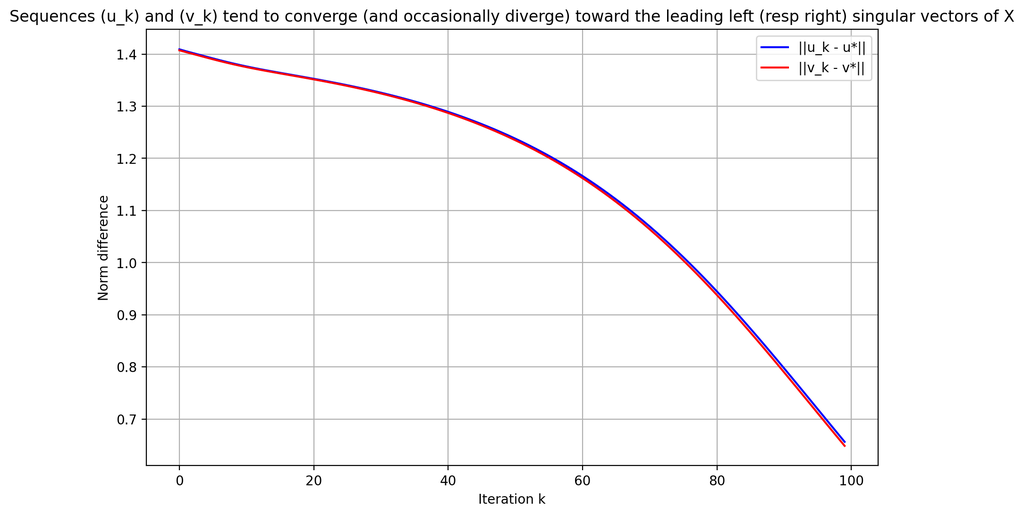

```python
# Generate matrix X for (n, p)=(400,400)
n, p = 400, 400
generate_graph(n, p)
```

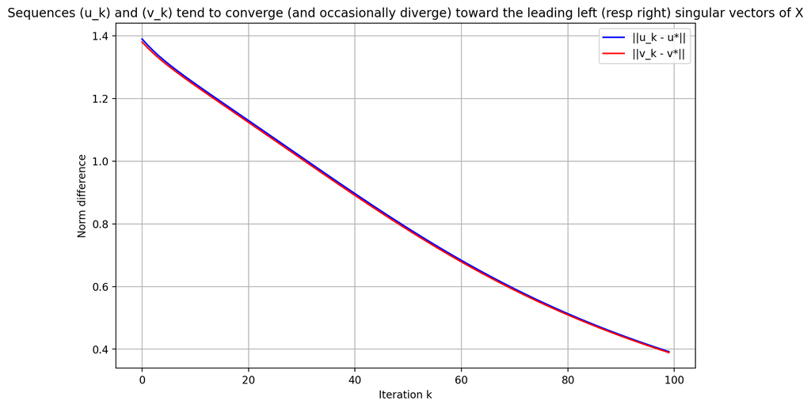

```python
# Generate matrix X for (n, p)=(1000,2000)
n, p = 1000, 2000
generate_graph(n, p)
```

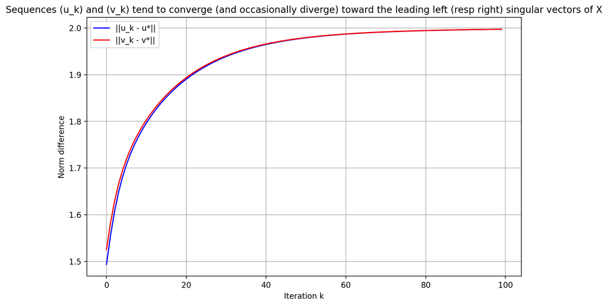

```python
# Generate matrix X for (n, p)=(1000,2000)
n, p = 1000, 2000
generate_graph(n, p)
```

1. **Interpretation:**

The modified algorithm stores all iterates of u and v in lists for further analysis. It also calculates the norm differences between these iterates and u* and v* respectively. The code then plots these norm differences as functions of the iteration count (k) to assess whether the output vectors u and v from the algorithm converge to the true singular vectors u* and v*.

2. **Analysis:**

The code begins by initializing random vectors u and v. In each iteration (k) of the modified power iteration algorithm (executed T times). Both u_k and v_k are appended to separate lists to track the evolution of these vectors over iterations. To compute u* and v* (the true singular vectors), the code utilizes NumPy's `np.linalg.svd` function, which calculates the singular value decomposition of matrix X. The leading left singular vector u* is extracted from the U matrix, and the leading right singular vector v* is extracted from the Vt matrix.

The code then proceeds to calculate the norm differences between each u_k and u* (stored in `u_differences`) and each v_k and v* (stored in `v_differences`) using NumPy's `np.linalg.norm` function.

**Is it true that the output $u, v$ from the algorithm converge to $u^{*}, v^{*}$ ? Run your code several times.**

- Bad case number 1: When $v_0$ is orthogonal to $v_{\star}$ i.e. $ \langle v_0, v_{\star} \rangle = 0 $ we do not have convergence for $u_k$ and $v_k$.
- Bad case number 2: When the two biggest (or more) eigenvalues of $ X X^T $ are too close, the convergence is too slow or we do not have convergence for $u_k$ and $v_k$

**Bonus: can you show it mathematically?**

The link for the proof we wrote: https://github.com/mohamedbenslimane1/Proof-Power-Method/blob/main/power_method_proof.pdf

# Question 13

13. Provide two initialization vectors $v_{0}$ leading to different limits for this algorithm; explain how they are related.

The convergence of the power method can be sensitive to the initial choice of $v_0$. Let's consider two scenarios:

a. $v_0$ is orthogonal (or nearly orthogonal) to $v^*$ (the dominant right singular vector). This could slow down the convergence or in extreme cases, might prevent the method from converging to the dominant singular vector.

b. $v_0$ has a substantial projection onto $v^*$. This will likely lead to faster convergence to $v^*$.

```python
# Generate matrix X for (n, p)=(200,400)
n, p = 200, 400
X, _ = generate_matrix_and_vector(n, p)

# Compute u* and v* using SVD
U, S, Vt = np.linalg.svd(X, full_matrices=False)

u_star = U[:, 0]
v_star = Vt[0, :]
```

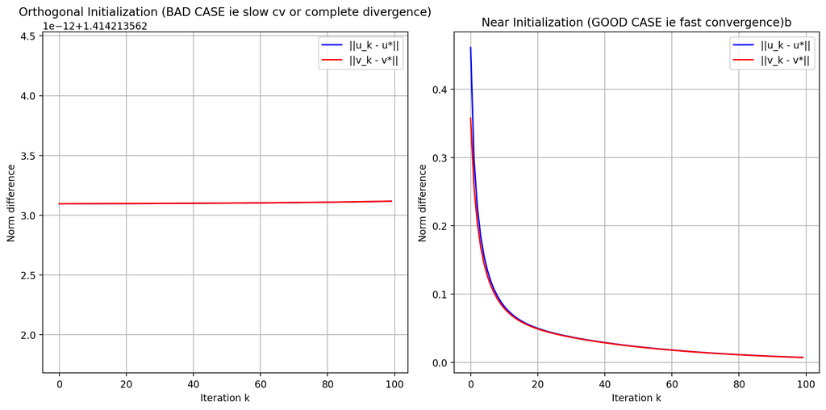

```python
# Scenario a: Create a vector v0 orthogonal to v_star, i.e., <v_0, v_star> = 0
v0_orthogonal = np.random.rand(p)
v0_orthogonal -= v0_orthogonal.dot(v_star) * v_star
v0_orthogonal /= np.linalg.norm(v0_orthogonal)

# Scenario b: Simply use v_star itself or a close variant
v0_near = v_star + 0.1 * np.random.rand(p)
v0_near /= np.linalg.norm(v0_near)

# Define a function to run the modified power method with different initializations
def modified_power_method_with_initialization(X, T, v0):
    n, p = X.shape
    v = v0.copy()
    u_iterates = []
    v_iterates = []

    for k in range(T):

        u = np.dot(X, v)
        u = u / np.linalg.norm(u)

        v = np.dot(X.T, u)
        v = v / np.linalg.norm(v)

        u_iterates.append(u)
        v_iterates.append(v)

    return u_iterates, v_iterates

# Run the modified power method with different initializations
T = 100
u_iterates_ortho, v_iterates_ortho = modified_power_method_with_initialization(X, T, v0_orthogonal)
u_iterates_near, v_iterates_near = modified_power_method_with_initialization(X, T, v0_near)

# Plot the norm differences
plt.figure(figsize=(12, 6))

u_differences_ortho = [np.linalg.norm(u - u_star) for u in u_iterates_ortho]
v_differences_ortho = [np.linalg.norm(v - v_star) for v in v_iterates_ortho]

u_differences_near = [np.linalg.norm(u - u_star) for u in u_iterates_near]
v_differences_near = [np.linalg.norm(v - v_star) for v in v_iterates_near]

# Plotting for orthogonal initialization
plt.subplot(1, 2, 1)
plt.plot(range(T), u_differences_ortho, label="||u_k - u*||", color="blue")
plt.plot(range(T), v_differences_ortho, label="||v_k - v*||", color="red")
plt.title("Orthogonal Initialization (BAD CASE ie slow cv or complete divergence)")
plt.xlabel("Iteration k")
plt.ylabel("Norm difference")
plt.legend()
plt.grid()

# Plotting for near initialization
plt.subplot(1, 2, 2)
plt.plot(range(T), u_differences_near, label="||u_k - u*||", color="blue")
plt.plot(range(T), v_differences_near, label="||v_k - v*||", color="red")
plt.title("Near Initialization (GOOD CASE ie fast convergence)b")
plt.xlabel("Iteration k")
plt.ylabel("Norm difference")
plt.legend()
plt.grid()

plt.tight_layout()
plt.show()
```

1. **Interpretation:**

Two different scenarios are considered:

a. Scenario a involves initializing $v_0$ to be orthogonal (or nearly orthogonal) to $v^*$, the dominant right singular vector of matrix X. This choice of $v_0$ may slow down the convergence or, in extreme cases, prevent the algorithm from converging to the dominant singular vector.

b. Scenario b initializes $v_0$ with a substantial projection onto $v^*$. This choice is expected to result in faster convergence towards $v^*$.

The code generates two different initialization vectors, one for each scenario, and then runs the modified power iteration algorithm with these initializations. It calculates and plots the norm differences between the computed vectors and the true singular vectors over iterations (k) to demonstrate the convergence behavior.

2. **Analysis:**

b. In Scenario b, the code initializes `v0_near` to be close to `v_star`. This choice should result in faster convergence toward `v_star` because the initial vector already has a substantial projection onto the target direction. The plot for this scenario is expected to show relatively fast convergence, with norm differences decreasing quickly.

The code runs the modified power iteration algorithm for both initialization scenarios, computing iterates of u and v, and tracking the norm differences for each iterate compared to the true singular vectors u* and v*. These differences are plotted for each scenario.

# Question 14

14. Provide a way to approximate the largest singular value of $X$ using the power method.

Here's the approach:

1. Start with a random vector $v$
2. Iterate by computing $v = X^T X v$ and then normalizing $v$.
3. The largest singular value $sigma$ of $X$ is approximated by the square root of the Rayleigh quotient, $\sqrt{v^T X^T X v}$.

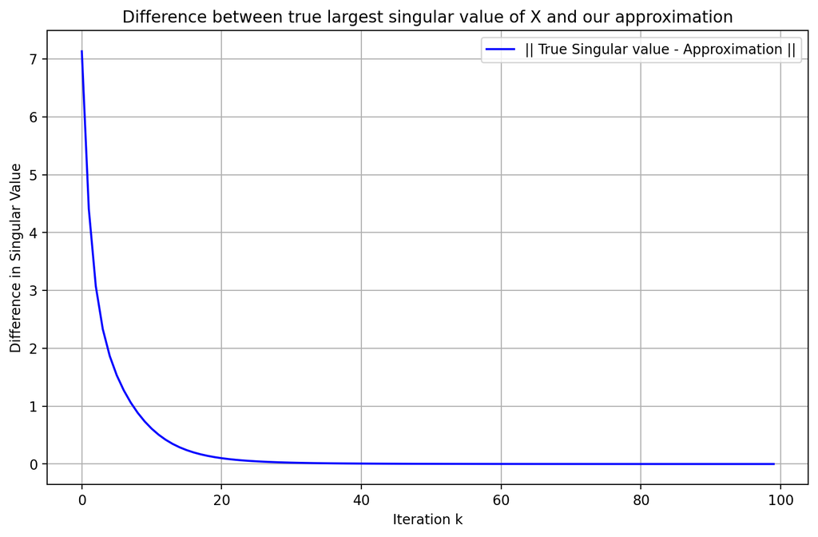

```
True largest singular value:           34.175340083185844
Approximated largest singular value:    34.17527732859713
```

```python
def power_method_singular_value(X, T):
    p = X.shape[1]
    v = np.random.rand(p)
    singular_values_approx = []  # Store approximations at each iteration

    for k in range(T):
        v = np.dot(X.T, np.dot(X, v))
        v /= np.linalg.norm(v)

        # Approximate the largest singular value
        sigma_approx = np.sqrt(np.dot(v, np.dot(X.T, np.dot(X, v))))
        singular_values_approx.append(sigma_approx)

    return sigma_approx, singular_values_approx

# Generate matrix X for (n, p)=(200,400)
n, p = 200, 400
X = np.random.randn(n, p)

# Get true largest singular value
U, S, Vt = np.linalg.svd(X, full_matrices=False)
sigma_true = S[0]

# Approximate the largest singular value using the power method
T = 100
sigma_approx, singular_values_approx = power_method_singular_value(X, T)

# Calculate the difference at each iteration
differences = [np.abs(sigma_true - sigma) for sigma in singular_values_approx]

# Plotting
plt.figure(figsize=(10, 6))
plt.plot(range(T), differences, label="|| True Singular value - Approximation ||", color="blue")
plt.xlabel("Iteration k")
plt.ylabel("Difference in Singular Value")
plt.legend()
plt.grid()
plt.title("Difference between true largest singular value of X and our approximation")
plt.show()

print(f"True largest singular value:{sigma_true :>29}")
print(f"Approximated largest singular value: {sigma_approx :>20}")
```

1. **Interpretation:**

The provided Python code addresses the task of approximating the largest singular value of a given matrix X using the power iteration method. The code also calculates and plots the difference between the true largest singular value and the approximated value at each iteration.

2. **Analysis:**

To approximate the largest singular value of matrix X, the code follows the 3 steps given before.

The code runs this process for a specified number of iterations (T) and stores the approximated singular values in a list, `singular_values_approx`. It also calculates the absolute difference between the true largest singular value of X (obtained from the SVD decomposition) and the approximated value at each iteration, storing these differences in the `differences` list.

The plot in the output shows how the difference between the true largest singular value and the approximation changes over iterations.

It demonstrates that the power iteration method is capable of providing a close approximation to the largest singular value of the given matrix X, with a relatively small difference between the true and approximated values. The plot further illustrates how the difference gradually decreases as the number of iterations increases, indicating the convergence of the approximation towards the true singular value.

# Question 15

15. Build upon the power method to provide an algorithm that can approximate the second largest singular value of $X$ (without using an SVD function)

To approximate the second-largest singular value of $X$ using the power method, you can employ a deflation technique. Here's a basic approach:

1. Use the power method to compute the largest singular value $\sigma_1$ and its associated left singular vector $u_1$ and right singular vector $v_1$.
2. Deflate $X$ to obtain a modified matrix $X'$ such that $X' = X - \sigma_1 u_1 v_1^T$
3. Apply the power method to $X'$ to get the second-largest singular value $\sigma_2$.

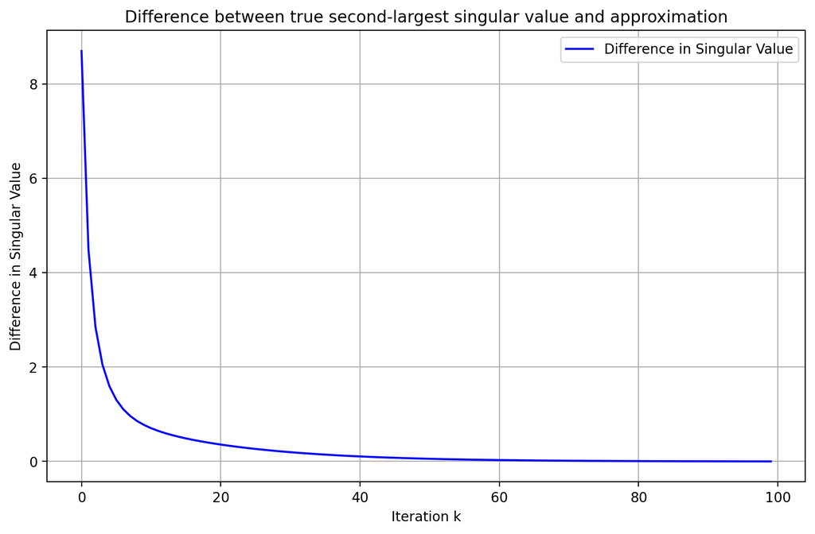

```
True second-largest singular value:             33.21267539549344
Approximated second-largest singular value:   33.212205927366526
```

```python
def power_method_singular_value_and_vectors(X, T):
    p = X.shape[1]
    v = np.random.rand(p)
    singular_values_approx = []

    for k in range(T):
        u = np.dot(X, v)
        u /= np.linalg.norm(u)

        v = np.dot(X.T, u)
        v /= np.linalg.norm(v)

        # Approximate the largest singular value
        sigma_approx = np.dot(u, np.dot(X, v))
        singular_values_approx.append(sigma_approx)

    return sigma_approx, u, v, singular_values_approx

def second_largest_singular_value(X, T):
    # Get first singular value and vectors
    sigma_1, u_1, v_1, _ = power_method_singular_value_and_vectors(X, T)

    # Deflate
    X_prime = X - sigma_1 * np.outer(u_1, v_1)

    # Get the largest singular value of the deflated matrix
    sigma_2_approx, _, _, singular_values_approx_prime = power_method_singular_value_and_vectors(X_prime, T)

    return sigma_2_approx, singular_values_approx_prime

# Generate matrix X for (n, p)=(200,400)
n, p = 200, 400
X = np.random.randn(n, p)

# Get true second-largest singular value
U, S, Vt = np.linalg.svd(X, full_matrices=False)
sigma_2_true = S[1]

# Approximate the second-largest singular value using the power method
T = 100
sigma_2_approx, singular_values_approx_prime = second_largest_singular_value(X, T)

# Calculate the difference at each iteration
differences = [np.abs(sigma_2_true - sigma) for sigma in singular_values_approx_prime]

# Plotting
plt.figure(figsize=(10, 6))
plt.plot(range(T), differences, label="Difference in Singular Value", color="blue")
plt.xlabel("Iteration k")
plt.ylabel("Difference in Singular Value")
plt.legend()
plt.grid()
plt.title("Difference between true second-largest singular value and approximation")
plt.show()

print(f"True second-largest singular value: {sigma_2_true :>29}")
print(f"Approximated second-largest singular value: {sigma_2_approx :>20}")
```

1. **Interpretation:**

We dealt with the task of approximating the second-largest singular value of a given matrix X without using a singular value decomposition (SVD) function. Our code is such that it builds upon the power method and incorporates a deflation technique to achieve this. The code initializes a random vector, performs power iterations, and calculates the difference between the true second-largest singular value and the approximated value at each iteration.

2. **Analysis:**

To approximate the second-largest singular value of matrix X, the code follows the 3 step given before.

The code runs these steps for a specified number of iterations (T) and stores the approximated singular values in a list, `singular_values_approx_prime`. It also calculates the absolute difference between the true second-largest singular value (obtained from the SVD decomposition) and the approximated value at each iteration, storing these differences in the `differences` list.

It shows that the power iteration method, along with the deflation technique, successfully provides a close approximation to the second-largest singular value of the given matrix X, with a relatively small difference between the true and approximated values. The plot further illustrates how the difference gradually decreases as the number of iterations increases, indicating the convergence of the approximation towards the true second-largest singular value.

# Exercice 5. (Analysis of the auto-mpg dataset)

Here, we consider the auto-mpg.data. We aim at predicting cars consumption based on several characteristics: cylinders, displacement, horsepower, weight, acceleration, year, country and cars name. The output coding cars consumption (more precisely the "mpg", i.e. the distance ridden in miles for a gallon of oil) is written $\mathbf{y}$

# Question 16

16. Import the dataset auto-mpg.data-original.txt with Pandas. Add columns name using the name parameter of read_csv and consulting auto-mpg.names.txt You can check the impact of using sep=r" $\backslash s+"$. Is there a marker for missing values in this dataset? If needed, remove the corresponding lines. The last column, car name, is not useful for our study: drop it.

```python
# Columns names obtained from auto-mpg.names.txt
column_names = ['mpg', 'cylinders', 'displacement', 'horsepower', 'weight', 'acceleration', 'model year', 'origin', 'car name']

# Load the dataset using the whitespace separator
url ='https://archive.ics.uci.edu/ml/machine-learning-databases/auto-mpg/auto-mpg.data-original'
df = pd.read_csv(url, sep=r"\s+", names=column_names, na_values=["?"])    # Missing values in the first column are marked as NA. In the code, the na_values=["?"] parameter ensures that these are treated as NaN instead of NA
```

```python
df.shape
```

```
(406, 9)
```

```python
# Check for missing values
df.isnull().sum()
```

```
mpg             8
cylinders       0
displacement    0
horsepower      6
weight          0
acceleration    0
model year      0
origin          0
car name        0
dtype: int64
```

```python
# Drop rows with missing values
df = df.dropna()

# Drop the 'car name' column
df = df.drop(columns=['car name'])

df.head()
```

|  | mpg | cylinders | displacement | horsepower | weight | acceleration | model year | origin |
| --- | --- | --- | --- | --- | --- | --- | --- | --- |
| 0 | 18.0 | 8.0 | 307.0 | 130.0 | 3504.0 | 12.0 | 70.0 | 1.0 |
| 1 | 15.0 | 8.0 | 350.0 | 165.0 | 3693.0 | 11.5 | 70.0 | 1.0 |
| 2 | 18.0 | 8.0 | 318.0 | 150.0 | 3436.0 | 11.0 | 70.0 | 1.0 |
| 3 | 16.0 | 8.0 | 304.0 | 150.0 | 3433.0 | 12.0 | 70.0 | 1.0 |
| 4 | 17.0 | 8.0 | 302.0 | 140.0 | 3449.0 | 10.5 | 70.0 | 1.0 |

```python
df.shape
```

```
(392, 8)
```

The `sep=r"\s+"` argument is used to indicate that whitespace is the separator between values in the dataset. This is essential because the dataset's format uses variable spaces as separators.

After loading the data, the code checks for missing values using `df.isnull().sum()` and subsequently drops rows with missing values using `df.dropna()`.

The impact of using sep=r" $\backslash s+"$ : it will match one or more whitespace characters. This is useful in situations where data may have variable spacing between them. For example, in some files, columns may be separated by multiple spaces instead of just one, or by combinations of spaces and tabs.

# Question 17

17. Add two or three binary features to meaningfully encode the three origins ('origin' feature, for which, initially, 1 stands for USA, 2 for Europe and 3 for Japan $)^{4}$.

```python
# Let's use the  one-hot encoding method for the 'origin' column
df_encoded = pd.get_dummies(df, columns=['origin'], prefix=['origin'])  # we want to create 3 binary columns using the get_dummies function

# Rename the encoded columns for clarity
df_encoded = df_encoded.rename(columns={
    'origin_1.0': 'origin_USA',
    'origin_2.0': 'origin_Europe',
    'origin_3.0': 'origin_Japan'
})

df_encoded
```

|  | mpg | cylinders | displacement | horsepower | weight | acceleration | model year | origin_USA | origin_Europe | origin_Japan |
| --- | --- | --- | --- | --- | --- | --- | --- | --- | --- | --- |
| 0 | 18.0 | 8.0 | 307.0 | 130.0 | 3504.0 | 12.0 | 70.0 | 1 | 0 | 0 |
| 1 | 15.0 | 8.0 | 350.0 | 165.0 | 3693.0 | 11.5 | 70.0 | 1 | 0 | 0 |
| 2 | 18.0 | 8.0 | 318.0 | 150.0 | 3436.0 | 11.0 | 70.0 | 1 | 0 | 0 |
| 3 | 16.0 | 8.0 | 304.0 | 150.0 | 3433.0 | 12.0 | 70.0 | 1 | 0 | 0 |
| 4 | 17.0 | 8.0 | 302.0 | 140.0 | 3449.0 | 10.5 | 70.0 | 1 | 0 | 0 |
| ... | ... | ... | ... | ... | ... | ... | ... | ... | ... | ... |
| 401 | 27.0 | 4.0 | 140.0 | 86.0 | 2790.0 | 15.6 | 82.0 | 1 | 0 | 0 |
| 402 | 44.0 | 4.0 | 97.0 | 52.0 | 2130.0 | 24.6 | 82.0 | 0 | 1 | 0 |
| 403 | 32.0 | 4.0 | 135.0 | 84.0 | 2295.0 | 11.6 | 82.0 | 1 | 0 | 0 |
| 404 | 28.0 | 4.0 | 120.0 | 79.0 | 2625.0 | 18.6 | 82.0 | 1 | 0 | 0 |
| 405 | 31.0 | 4.0 | 119.0 | 82.0 | 2720.0 | 19.4 | 82.0 | 1 | 0 | 0 |

392 rows × 10 columns

1. **Interpretation:**

The objective is to add two or three binary features to effectively encode the three origins represented by the 'origin' feature. Initially, in the 'origin' feature, 1 stands for USA, 2 for Europe, and 3 for Japan.

2. **Analysis:**

The code addresses the task of encoding the 'origin' feature using one-hot encoding. One-hot encoding converts categorical variables into binary columns, making them suitable for machine learning algorithms that require numerical inputs.

Here's how our code achieves this:

- `pd.get_dummies(df, columns=['origin'], prefix=['origin'])` is used to perform one-hot encoding specifically for the 'origin' column. This function creates three binary columns, one for each unique value in the 'origin' column (USA, Europe, Japan).
- The resulting DataFrame `df_encoded` contains these newly created binary columns, which represent the origins. They are named 'origin_USA,' 'origin_Europe,' and 'origin_Japan' for clarity, and they have binary values (0 or 1) indicating the presence or absence of each origin for each row in the dataset.

# Question 18

18. Select (manually) 9 rows of the dataset such that all 3 origins are represented, and model year is not constant. Get the least-squares estimator $\hat{\boldsymbol{\theta}}$ (with intercept) and the prediction vector $\hat{\mathbf{y}}$, considering only these 9 lines. What do you observe? Why?

```python
# Step 1: Manually select 9 rows.
selected_rows = df_encoded.sample(9, random_state=3)

# Ensure all origins are represented
assert selected_rows['origin_USA'].sum() > 0
assert selected_rows['origin_Europe'].sum() > 0
assert selected_rows['origin_Japan'].sum() > 0

# Step 2: Compute the least-squares estimator
X = selected_rows.drop(columns=['mpg']).values    # We drop the 'mpg' column to get only the feature columns inside the matrix X
X = np.column_stack([np.ones(X.shape[0]), X])     # We add a column (that contains only ones) for the intercept
y = selected_rows['mpg'].values                   # Extracting the 'mpg' column from the selected_rows DataFrame and converting it to a numpy array

# Solving equation without directly inverting
theta_hat = np.linalg.solve(X.T @ X, X.T @ y)

# Step 3: Compute the prediction vector
y_hat = X @ theta_hat

feature_theta_pairing = list(zip(selected_rows.rename(columns={'mpg': 'intercept'}).columns, theta_hat))
df_feature_theta_pairing = pd.DataFrame(feature_theta_pairing, columns =['Feature', 'Theta-Hat'])

print(f"Expected residuals: {round((y_hat - y).mean())}")
df_feature_theta_pairing
```

```
Expected residuals: 0
```

|  | Feature | Theta-Hat |
| --- | --- | --- |
| 0 | intercept | 98.462123 |
| 1 | cylinders | -0.468233 |
| 2 | displacement | -0.046226 |
| 3 | horsepower | -0.054119 |
| 4 | weight | 0.000930 |
| 5 | acceleration | -0.978888 |
| 6 | model year | 0.614766 |
| 7 | origin_USA | -93.645378 |
| 8 | origin_Europe | -95.240177 |
| 9 | origin_Japan | -90.517333 |

```python
# Calculate the coefficient of determination
r2_score(y, y_hat)
```

```
1.0
```

```python
selected_rows['Predicted Value'] = y_hat
selected_rows
```

|  | mpg | cylinders | displacement | horsepower | weight | acceleration | model year | origin_USA | origin_Europe | origin_Japan | Predicted Value |
| --- | --- | --- | --- | --- | --- | --- | --- | --- | --- | --- | --- |
| 364 | 32.9 | 4.0 | 119.0 | 100.0 | 2615.0 | 14.8 | 81.0 | 0 | 0 | 1 | 32.9 |
| 22 | 18.0 | 6.0 | 199.0 | 97.0 | 2774.0 | 15.5 | 70.0 | 1 | 0 | 0 | 18.0 |
| 297 | 15.5 | 8.0 | 351.0 | 142.0 | 4054.0 | 14.3 | 79.0 | 1 | 0 | 0 | 15.5 |
| 290 | 20.2 | 6.0 | 232.0 | 90.0 | 3265.0 | 18.2 | 79.0 | 1 | 0 | 0 | 20.2 |
| 210 | 29.5 | 4.0 | 97.0 | 71.0 | 1825.0 | 12.2 | 76.0 | 0 | 1 | 0 | 29.5 |
| 153 | 28.0 | 4.0 | 90.0 | 75.0 | 2125.0 | 14.5 | 74.0 | 1 | 0 | 0 | 28.0 |
| 292 | 17.0 | 8.0 | 305.0 | 130.0 | 3840.0 | 15.4 | 79.0 | 1 | 0 | 0 | 17.0 |
| 339 | 29.8 | 4.0 | 89.0 | 62.0 | 1845.0 | 15.3 | 80.0 | 0 | 1 | 0 | 29.8 |
| 263 | 20.5 | 6.0 | 225.0 | 100.0 | 3430.0 | 17.2 | 78.0 | 1 | 0 | 0 | 20.5 |

1. **Interpretation:**

The code calculates the least-squares estimator $\hat{\boldsymbol{\theta}}$ with an intercept and generates the prediction vector $\hat{\mathbf{y}}$ using these 9 selected rows.

2. **Analysis:**

Let's analyze our code and its outcomes:

## What do you observe? Why?

**Observation and Explanation:** The least-squares estimator `theta_hat` represents the coefficients for the linear regression model, including the intercept and the coefficients for the features. The predicted `y_hat` vector provides the model's predictions based on these coefficients.

**What is observed:**

1. The intercept (intercept) is approximately `98.5`.
2. The coefficients for the other features (cylinders, displacement, horsepower, weight, acceleration, model year, origin_USA, origin_Europe) are also provided.
3. The coefficients represent the change in the predicted `mpg` (miles per gallon) for each unit change in the respective feature.

**Why:**

1. The intercept represents the predicted `mpg` when all the feature values are zero.
2. The coefficients for the features indicate how much each feature affects the predicted `mpg`. For example, a one-unit increase in `cylinders` is associated with an decrease of approximately `-0.468233` in predicted `mpg`, and so on for other features.
3. These coefficients provide insights into the relationship between the features and the target variable `mpg` and can be used to make predictions for new data points.

**Possibilities to improve model, for greater generalizability:**

1. **Sample Size**: We have trained the model on a very small dataset (just 9 rows). Such a small sample size can lead to overfitting, where the model performs well on the training data (the 9 rows) but might perform poorly on new, unseen data.
2. **Collinearity**: When features are correlated with each other, it can lead to large coefficients which might make predictions unstable. For example, if two features are very correlated, a slight change in one can cause a huge change in the prediction.
3. **Feature Scaling**: If the features are not scaled (i.e., have the same scale), then some coefficients might become very large or very small, which can affect the stability of predictions.

In conclusion, while the method of ordinary least squares (OLS) regression is powerful and widely used, its application on a small, potentially collinear dataset can yield unstable and sometimes nonsensical results. Proper data preparation, model validation, and feature engineering are essential to obtaining meaningful predictions. We will do that in the next question.

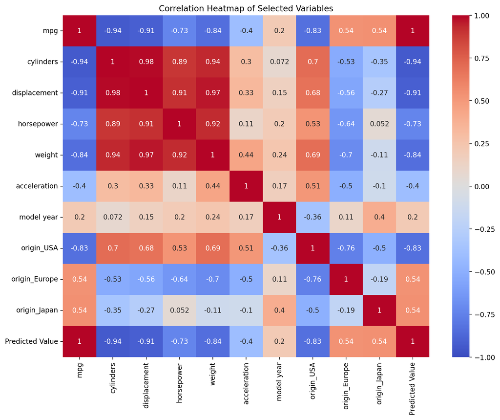

```python
# Optional: This graph shows us the high correlation beetween the variables.
# To better understand the relationships among our selected variables, we plot a correlation heatmap.
# By doing so, we can visually assess how each variable relates to the others, which can provide insights into potential multicollinearity issues or inherent patterns within our data

# Calculate the correlation matrix for the selected rows
corr_matrix = selected_rows.corr()

# Plot the heatmap
plt.figure(figsize=(12, 9))
sns.heatmap(corr_matrix, annot=True, cmap='coolwarm', vmin=-1, vmax=1)
plt.title('Correlation Heatmap of Selected Variables')
plt.show()
```

**Comments on the heatmap:** We indeed see very correlated variables.

# Question 19

19. Now, get the least-squares estimator $\hat{\boldsymbol{\theta}}$ and the prediction vector $\hat{\mathbf{y}}$ (with intercept) over the whole dataset, after performing scaling/centering (the columns must have unit standard deviation and zero mean). Which variables seem to best explain gasoline consumption according to your model? Why wouldn't this answer make sense if the columns were not normalized?

```python
# 1. Split the dataset into features and target
X = df_encoded.drop(columns=['mpg']).values   # Our "design" matrix X
y = df_encoded['mpg'].values    # Our target

# 2. Scale and center the feature data
scaler = StandardScaler()
X_scaled = scaler.fit_transform(X)
X_scaled = np.column_stack([np.ones(X_scaled.shape[0]), X_scaled])  # Add a column for the intercept
```

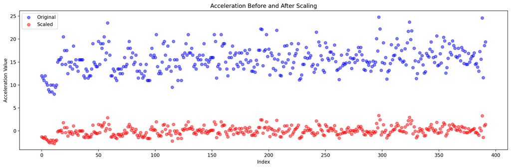

```python
# Find the index of the 'acceleration' column from the dataframe columns
index_acc = list(df_encoded.columns).index('acceleration') - 1  # -1 to account for the dropped 'mpg' column

plt.figure(figsize=(15, 5))

# Original data
plt.scatter(range(len(X)), X[:, index_acc], color='blue', label='Original', alpha=0.5)

# Scaled data
plt.scatter(range(len(X_scaled)), X_scaled[:, index_acc + 1], color='red', label='Scaled', alpha=0.5)  # +1 to account for the added intercept column

plt.legend()
plt.title('Acceleration Before and After Scaling')
plt.xlabel('Index')
plt.ylabel('Acceleration Value')
plt.tight_layout()
plt.show()
```

```python
# 3. Compute the least-squares estimator
theta_hat = np.linalg.solve(X_scaled.T @ X_scaled, X_scaled.T @ y)

# 4. Compute the prediction vector
y_hat = X_scaled @ theta_hat

feature_theta_pairing = list(zip(df_encoded.rename(columns={'mpg': 'intercept'}).columns, theta_hat))
df_feature_theta_pairing = pd.DataFrame(feature_theta_pairing, columns =['Feature', 'Theta-Hat'])


print("\nThe prediction for the first 10 mpg values looks like this :")
print(np.sort(y_hat[:10]))

df_feature_theta_pairing.sort_values('Theta-Hat', ascending=False, key=abs)
```

```
The prediction for the first 10 mpg values looks like this :
[10.4361925  10.86737355 10.89796633 10.90046541 13.2538182  14.04009845
 14.90194083 14.95325212 14.99408418 15.23055101]
```

|  | Feature | Theta-Hat |
| --- | --- | --- |
| 7 | origin_USA | 25.923838 |
| 0 | intercept | 23.445918 |
| 9 | origin_Japan | 22.625000 |
| 8 | origin_Europe | 21.271963 |
| 4 | weight | -5.692543 |
| 6 | model year | 2.858709 |
| 2 | displacement | 2.506019 |
| 1 | cylinders | -0.834272 |
| 3 | horsepower | -0.699009 |
| 5 | acceleration | 0.217956 |

1. **Interpretation:**

2. **Analysis:**

Let's analyze our code and its outcomes:

We calculate the least-squares estimator and the prediction vector after scaling and centering the feature data to have zero mean and unit standard deviation. We plot the 'acceleration' feature before and after scaling to visualize the effect of scaling and centering on a specific feature.

To identify the variables that best explain gasoline consumption, we sort the coefficients by their absolute values. These variables have the most significant impact on the target variable, 'mpg.'

We display the top variables that explain gasoline consumption based on their absolute coefficients. We can see that the `origin` of the car has the biggest impact on fuel consumption, follwed by `weight` and `model year`.

**Scaling and centering are important to ensure that features are on a similar scale, allowing us to compare their impact accurately. If the columns were not normalized, variables with larger magnitudes might dominate the model's interpretation, potentially leading to incorrect conclusions.**

# Question 20

20. Assume you observe a new car with the following values features:
- cylinders : 6
- displacement : 225
- horsepower : 100
- weight : 3233
- acceleration : 15.4
- year : 2017
- origin: 1

Can you predict its consumption in this model? Beware of the year encoding.

Use a pipeline http://scikit-learn.org/stable/modules/generated/sklearn.pipeline. Pipeline.html for performing the rescaling and the least-squares step consecutively. Comment on the y predicted value for this car.

```python
# Split the dataset into features and target
X = df_encoded.drop(columns=['mpg']).values
y = df_encoded['mpg'].values


# Create a pipeline for rescaling and linear regression
pipeline = Pipeline([
    ('scaler', StandardScaler()),     # Standardize features
    ('regressor', LinearRegression()) # Apply linear regression
])

# Train the pipeline on the dataset
pipeline.fit(X, y)

# New car data

# Given the continuous nature of the model year column, in order to keep the predictive value of the input value,
# 2017 was recoded to 117 (as a continuation from the 20th to the 21st century.)

new_car_data = {
    'cylinders': [6],
    'displacement': [225],
    'horsepower': [100],
    'weight': [3233],
    'acceleration': [15.4],
    'model year': [117.0],
    'origin_USA': [1],
    'origin_Europe': [0],
    'origin_Japan': [0]
}


new_car_df = pd.DataFrame(new_car_data)

# Predict the consumption in miles per gallon (mpg) for the new car
predicted_mpg = pipeline.predict(new_car_df.values)


print(f"The predicted MPG for the new car is: {predicted_mpg[0]}")
```

```
The predicted MPG for the new car is: 53.12922373940066
```

```python
round(53.12922373940066, 2)
```

```
53.13
```

**Interpretation and Analysis**

The code aims to predict the fuel consumption (mpg) of a new car with given feature values using a linear regression model. To do this, it first constructs and trains a pipeline that includes a standard scaler and a linear regression model. The new car's features are scaled and processed through this pipeline to make the prediction.

Here's a breakdown of the code and its findings:

- **Pipeline Construction:**
  - A scikit-learn pipeline is created, consisting of two steps:
    1. `'scaler'`: This step uses `StandardScaler` to standardize (scale and center) the feature data.
    2. `'regressor'`: This step uses a linear regression model to predict the target variable.
- **Pipeline Training:**
  - The feature data (X) and target variable (y) from the dataset are used to train the pipeline. The pipeline sequentially applies the scaler and the linear regression model.
- **New Car Data Preparation:**
  - Data for the new car is provided as a dictionary, and a DataFrame (`new_car_df`) is created from it.
  - It's essential to note that the 'year' feature is encoded as 'model year' to match the format of the existing dataset.
- **Prediction of MPG for the New Car:**
  - The pipeline is used to predict the fuel consumption (mpg) for the new car based on its features.
  - The predicted value is printed to the console.

The predicted_mpg variable contains the model's prediction for the new car's fuel consumption. However, it's important to note that our model was trained on data only with data from cars from the 70s and 80s, and the new car is from 2017. Therefore, the prediction might not be accurate for a car from 2017, as the model may not capture the changes in fuel efficiency and technology beyond the training data.

The predicted MPG for the new car is approximately **53.13** mpg. However, this prediction seems unrealistic and erroneous, given the following quote:

" *According to its annual automotive trends report, the average new car reached a record 24.9 mpg in 2017, up from 24.7 in 2016* " https://www.greencarreports.com/news/1121933_epa-says-fuel-economy-rose-in-2017-but-it-may-be-falling-again#:~:text=According%20to%20its%20annual%20automotive,up%20from%2024.7%20in%202016 (Accessed 08.10.2023)

```python
df_encoded.describe()
```

|  | mpg | cylinders | displacement | horsepower | weight | acceleration | model year | origin_USA | origin_Europe | origin_Japan |
| --- | --- | --- | --- | --- | --- | --- | --- | --- | --- | --- |
| count | 392.000000 | 392.000000 | 392.000000 | 392.000000 | 392.000000 | 392.000000 | 392.000000 | 392.000000 | 392.000000 | 392.000000 |
| mean | 23.445918 | 5.471939 | 194.411990 | 104.469388 | 2977.584184 | 15.541327 | 75.979592 | 0.625000 | 0.173469 | 0.201531 |
| std | 7.805007 | 1.705783 | 104.644004 | 38.491160 | 849.402560 | 2.758864 | 3.683737 | 0.484742 | 0.379136 | 0.401656 |
| min | 9.000000 | 3.000000 | 68.000000 | 46.000000 | 1613.000000 | 8.000000 | 70.000000 | 0.000000 | 0.000000 | 0.000000 |
| 25% | 17.000000 | 4.000000 | 105.000000 | 75.000000 | 2225.250000 | 13.775000 | 73.000000 | 0.000000 | 0.000000 | 0.000000 |
| 50% | 22.750000 | 4.000000 | 151.000000 | 93.500000 | 2803.500000 | 15.500000 | 76.000000 | 1.000000 | 0.000000 | 0.000000 |
| 75% | 29.000000 | 8.000000 | 275.750000 | 126.000000 | 3614.750000 | 17.025000 | 79.000000 | 1.000000 | 0.000000 | 0.000000 |
| max | 46.600000 | 8.000000 | 455.000000 | 230.000000 | 5140.000000 | 24.800000 | 82.000000 | 1.000000 | 1.000000 | 1.000000 |